# The curse of spatial scale in population statistics and how GIS can help

Antti Härkönen

2022-08-08

# MAUP

## Ecological fallacy

- common statistical problem that arises from aggregation
- several features are combined, they may create seemingly co-occurring phenomena
- these may be interpreted as causal relationships

## Example: Treaty of Nöteborg and its impact

- supposedly the 1323 border influences demographic and economic differences between eastern and western Finland
- but in reality:
  - no set border for the most part
  - no direct causal connection
- seeing patterns that look vaguely like the 1323 border is an example of ecological fallacy

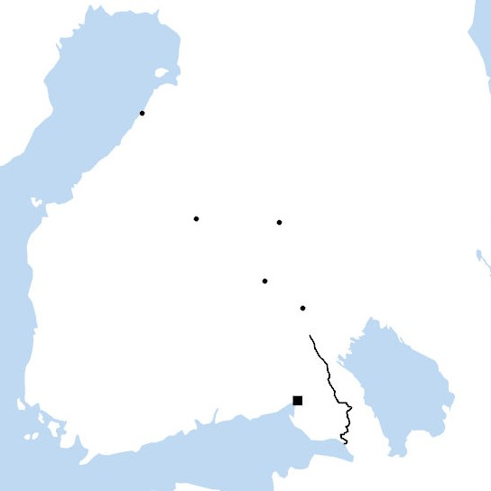

Nöteborg Treaty 1323

## MAUP

- modifiable areal unit problem
- subset of ecological fallacy
- areal units can change arbitrarily
- rarely discussed in historical studies

## Administrative units

- quantitative historical studies usually use data collected by administrative unit
- common in:
  - economic history/cliometrics
  - historical demography
- administrative units keep changing
  - diachronic change
  - local differences
- Eurostat’s [NUTS](https://ec.europa.eu/statistical-atlas/viewer/) areas are very different between countries
  - *disgusting*
  - leads to misleading choropleth maps and statistical analyses

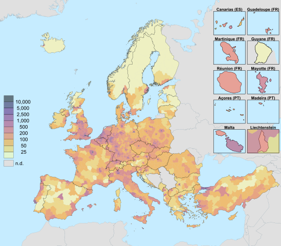

Population density by NUTS-3 area

dieghernan, Wikimedia commons

# Solutions

## Dealing with spatial issues

- removing problematic areas
  - analyses are weaker
  - can introduce bias (e.g. quickly changing areas can be growing especially fast)
- ignoring problems completely

## Fine-grained data

- fine-grained spatial analysis reduces the effects of spatial scale
- problems:
  - not enough ready-made data available
  - solutions to such problems require vast amounts of work

## Adjusting areal units

- estimating and correcting for the impact of changing borders
  - used in Historical GIS projects (e.g. GBHGIS)
- imputation and interpolation
  - requires statistical knowledge
  - potentially *very* deceptive

# Vyborg

## Finnish and Russian population

- large Russian minority before 1917
- Orthodoxy used as a proxy for Russian nationality

## Changing segregation

- town space changes
- so do spatial units
- St. Petersburg suburb shrinks over a long period
  - poll tax records change yearly

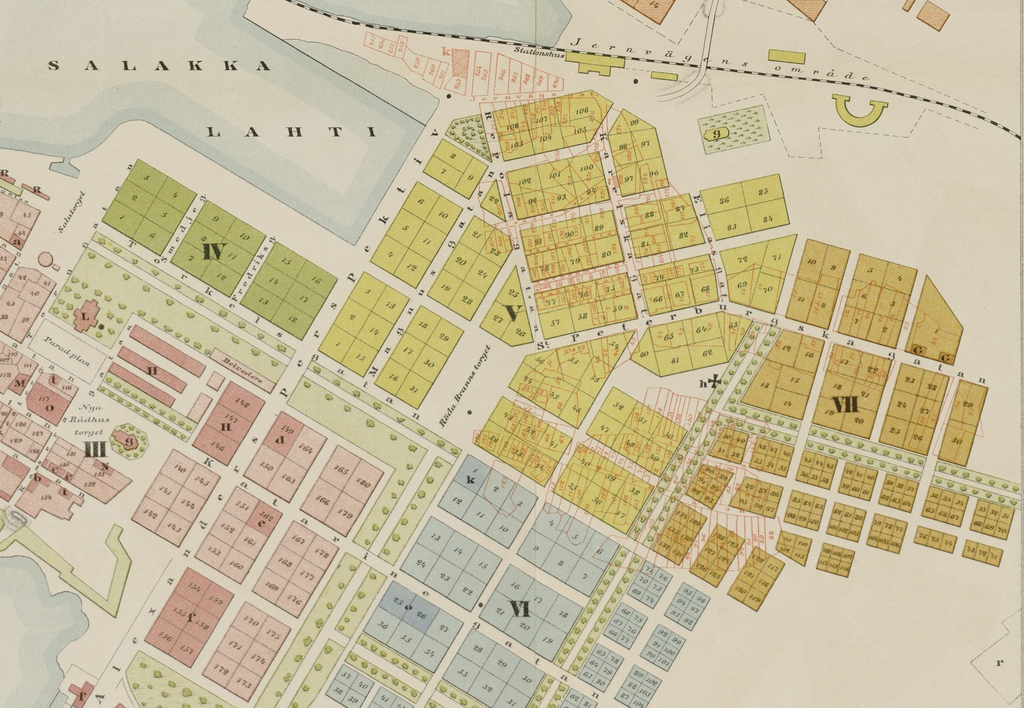

## Fine-grained analysis

- population located down to plot level
- raster file representing population density
  - 50 by 50 meter resolution
  - continuous population density model
- almost ignores changes in suburb boundaries

# Summary

## Problems

- MAUP
- ecological fallacy
- lack of data

## Solutions

- improved data collection
- interpolation techniques
- problems with spatial scale can never be fully solved, as data is inherently full of compromises